# Marvin the Robot Experiments

# Experiment Three

Experiment Three uses only two arguments, with the Special-Transformo-Box 3000 acting as the **apply** function. This further addresses the problem of treating this task like a sequence task. With one and two examples, the number of systems is small.

[output not shown]

#### Run 1 example version:

a -> BOX -> a a -> BOX -> b

#### Why is Constant difficult?

#### What kind of model produces the funky results for Constant?

#### Can we build up further? 3 Examples?

### Pre-processing data

```r
library(ggplot2)
```

### Plotting the responses

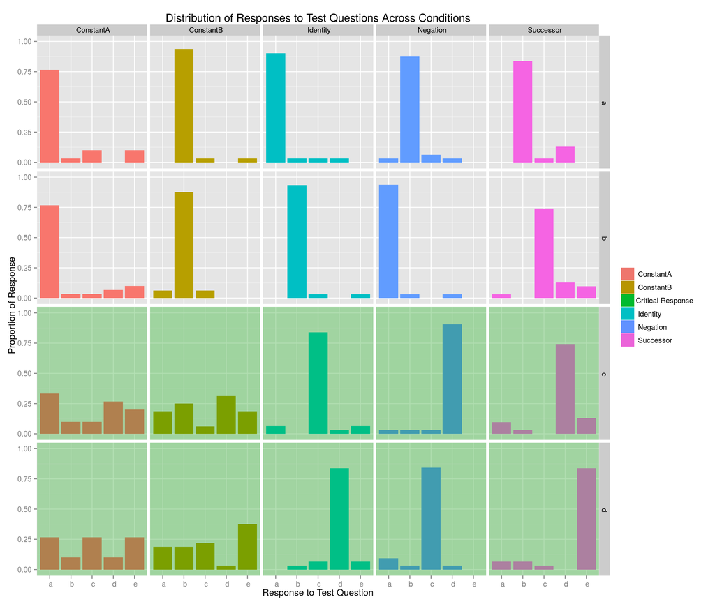

```r
plt = ggplot(data,aes(x=Response,fill=ConditionID))+

  geom_histogram(aes(y=(..count..)/tapply(..count..,..PANEL..,sum)[..PANEL..]))+
  #geom_histogram()+
  facet_grid(~Question~ConditionID)+
  xlab("Response to Test Question")+
  ylab("Proportion of Response")+
  geom_rect(data = subset(data,Question == ' c' & ConditionID==" ConstantA"),aes(fill="Critical Response"),xmin = -Inf,xmax = Inf,ymin = -Inf,ymax = Inf,alpha = .01) +
  geom_rect(data = subset(data,Question == ' c' & ConditionID==" ConstantB"),aes(fill="Critical Response"),xmin = -Inf,xmax = Inf,ymin = -Inf,ymax = Inf,alpha = .01) +
  geom_rect(data = subset(data,Question == ' d' & ConditionID==" ConstantA"),aes(fill="Critical Response"),xmin = -Inf,xmax = Inf,ymin = -Inf,ymax = Inf,alpha = .01) +
  geom_rect(data = subset(data,Question == ' d' & ConditionID==" ConstantB"),aes(fill="Critical Response"),xmin = -Inf,xmax = Inf,ymin = -Inf,ymax = Inf,alpha = .01) +
  geom_rect(data = subset(data,Question == ' c' & ConditionID==" Identity"),aes(fill="Critical Response"),xmin = -Inf,xmax = Inf,ymin = -Inf,ymax = Inf,alpha = .01) +
  geom_rect(data = subset(data,Question == ' d' & ConditionID==" Identity"),aes(fill="Critical Response"),xmin = -Inf,xmax = Inf,ymin = -Inf,ymax = Inf,alpha = .01) +
  geom_rect(data = subset(data,Question == ' c' & ConditionID==" Negation"),aes(fill="Critical Response"),xmin = -Inf,xmax = Inf,ymin = -Inf,ymax = Inf,alpha = .01) +
  geom_rect(data = subset(data,Question == ' d' & ConditionID==" Negation"),aes(fill="Critical Response"),xmin = -Inf,xmax = Inf,ymin = -Inf,ymax = Inf,alpha = .01) +
  geom_rect(data = subset(data,Question == ' c' & ConditionID==" Successor"),aes(fill="Critical Response"),xmin = -Inf,xmax = Inf,ymin = -Inf,ymax = Inf,alpha = .01) +
  geom_rect(data = subset(data,Question == ' d' & ConditionID==" Successor"),aes(fill="Critical Response"),xmin = -Inf,xmax = Inf,ymin = -Inf,ymax = Inf,alpha = .01) +
  ggtitle("Distribution of Responses to Test Questions Across Conditions")+
  ylim(0,1)+
  theme(legend.title=element_blank())
plt
```

### Reaction Time Over Trials Between Conditions

#### This may indicate how “easy” each condition is, or possibly hint to the simplicity of hypotheses used.

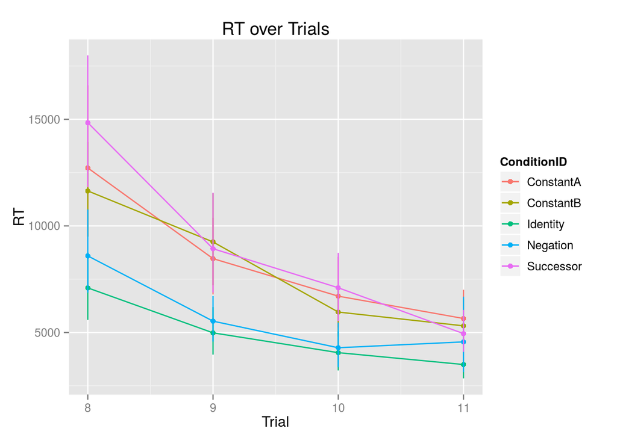

```r
plt=ggplot(data,aes(Trial,RT,color=ConditionID))+
  stat_summary(fun.y=mean,geom="line")+
  stat_summary(fun.data=mean_cl_boot,geom="pointrange")+
  ggtitle("RT over Trials")
plt
```

## Questions

#### What generative model makes this response to Constant the simplest hypothesis?

#### Can we find a fitting combinator basis?

#### If we do find a combinator basis that fits nicely, then what are we proposing? That generalizations are performed in this strictly functional, lambda-calculus-like way? Or that combinatory logic is a good area to explore when discussing mental representations, as given by this kind of evidence.

#### Is the LOT model better? (probably, if you have super specific primitives…)

#### What else can we say about people’s generalizations in this totally “pure” task?